# SI 370 - Homework #1: Data Manipulation and Preliminary Analyses

## Background

This homework assignment focuses on the exploration and analysis of historical data from the Olympic games. The description of the data includes the following:

> This is a historical dataset on the modern Olympic Games, including all the Games from Athens 1896 to Rio 2016. I scraped this data from www.sports-reference.com in May 2018.

Your main task in this assignment is to explore the data *using the data manipulation and analysis methods we covered in class* as well as those in the assigned readings. You may need to consult pandas documentation, Stack Overflow, or other online resources.

**You should also feel free to ask questions on Slack!**

A total of 30 points is available in this homework assignment.

Each of Questions 1-5 are worth 5 points each. Points will be allocated according to the following rubric:

- 5 points: Question is correctly and completely answered. Answer consists of well-written code that conforms to [PEP 8](https://www.python.org/dev/peps/pep-0008/) guidelines and is accompanied by a written interpretation in a Markdown block. Written interpretation does not contain spelling, grammar or stylistic errors (see https://faculty.washington.edu/heagerty/Courses/b572/public/StrunkWhite.pdf for a detailed specifications).
- 4 points: Answer is mostly complete and correct; two or fewer noticeable omissions or errors. Minor stylistic flaws, either in code or in written interpretation.
- 3 points: Answer has significant omissions or errors; Noticeable departure from PEP-8 guildelines and/or moderate spelling, grammar, or style issues in written interpretations.
- 2 points: Question is perfunctorily attempted. Substantial parts are missing or incorrect.
- 0 points: Question not attempted.

A bonus question worth up to 5 points is also available.

## First, read about the data (athlete_events.csv) from:

- https://www.kaggle.com/heesoo37/120-years-of-olympic-history-athletes-and-results

Note: The data file is available via https://bit.ly/2lUIi5P, which you should use in your work below.

## Answer the questions below.

For each question, you should

1. Write code using Python and pandas that can help you answer the following questions, and
2. Explain your answers in plain English. You should use complete sentences that would be understood by an educated professional who is not necessarily a data scientist (like a product manager).

### Q1 Load and describe the dataset. (5pt)

- How many number rows and columns are there in the data frame?
- Provide summary statistics (i.e. use the .describe() function) for the numeric variables (other than ID) from the athlete_events.csv file.

Dependencies:

```python
import pandas as pd
import numpy as np
import seaborn as sns
from scipy import stats
import matplotlib.pyplot as plt
```

Extract:

```python
url = 'https://bit.ly/2lUIi5P'
olympics = pd.read_csv(url)\
             .set_index('ID')
```

```python
olympics
```

| ID | Name | Sex | Age | Height | Weight | Team | NOC | Games | Year | Season | City | Sport | Event | Medal |
| --- | --- | --- | --- | --- | --- | --- | --- | --- | --- | --- | --- | --- | --- | --- |
| 1 | A Dijiang | M | 24.0 | 180.0 | 80.0 | China | CHN | 1992 Summer | 1992 | Summer | Barcelona | Basketball | Basketball Men's Basketball | NaN |
| 2 | A Lamusi | M | 23.0 | 170.0 | 60.0 | China | CHN | 2012 Summer | 2012 | Summer | London | Judo | Judo Men's Extra-Lightweight | NaN |
| 3 | Gunnar Nielsen Aaby | M | 24.0 | NaN | NaN | Denmark | DEN | 1920 Summer | 1920 | Summer | Antwerpen | Football | Football Men's Football | NaN |
| 4 | Edgar Lindenau Aabye | M | 34.0 | NaN | NaN | Denmark/Sweden | DEN | 1900 Summer | 1900 | Summer | Paris | Tug-Of-War | Tug-Of-War Men's Tug-Of-War | Gold |
| 5 | Christine Jacoba Aaftink | F | 21.0 | 185.0 | 82.0 | Netherlands | NED | 1988 Winter | 1988 | Winter | Calgary | Speed Skating | Speed Skating Women's 500 metres | NaN |
| 5 | Christine Jacoba Aaftink | F | 21.0 | 185.0 | 82.0 | Netherlands | NED | 1988 Winter | 1988 | Winter | Calgary | Speed Skating | Speed Skating Women's 1,000 metres | NaN |
| 5 | Christine Jacoba Aaftink | F | 25.0 | 185.0 | 82.0 | Netherlands | NED | 1992 Winter | 1992 | Winter | Albertville | Speed Skating | Speed Skating Women's 500 metres | NaN |
| 5 | Christine Jacoba Aaftink | F | 25.0 | 185.0 | 82.0 | Netherlands | NED | 1992 Winter | 1992 | Winter | Albertville | Speed Skating | Speed Skating Women's 1,000 metres | NaN |
| 5 | Christine Jacoba Aaftink | F | 27.0 | 185.0 | 82.0 | Netherlands | NED | 1994 Winter | 1994 | Winter | Lillehammer | Speed Skating | Speed Skating Women's 500 metres | NaN |
| 5 | Christine Jacoba Aaftink | F | 27.0 | 185.0 | 82.0 | Netherlands | NED | 1994 Winter | 1994 | Winter | Lillehammer | Speed Skating | Speed Skating Women's 1,000 metres | NaN |
| 6 | Per Knut Aaland | M | 31.0 | 188.0 | 75.0 | United States | USA | 1992 Winter | 1992 | Winter | Albertville | Cross Country Skiing | Cross Country Skiing Men's 10 kilometres | NaN |
| 6 | Per Knut Aaland | M | 31.0 | 188.0 | 75.0 | United States | USA | 1992 Winter | 1992 | Winter | Albertville | Cross Country Skiing | Cross Country Skiing Men's 50 kilometres | NaN |
| 6 | Per Knut Aaland | M | 31.0 | 188.0 | 75.0 | United States | USA | 1992 Winter | 1992 | Winter | Albertville | Cross Country Skiing | Cross Country Skiing Men's 10/15 kilometres Pu... | NaN |
| 6 | Per Knut Aaland | M | 31.0 | 188.0 | 75.0 | United States | USA | 1992 Winter | 1992 | Winter | Albertville | Cross Country Skiing | Cross Country Skiing Men's 4 x 10 kilometres R... | NaN |
| 6 | Per Knut Aaland | M | 33.0 | 188.0 | 75.0 | United States | USA | 1994 Winter | 1994 | Winter | Lillehammer | Cross Country Skiing | Cross Country Skiing Men's 10 kilometres | NaN |
| 6 | Per Knut Aaland | M | 33.0 | 188.0 | 75.0 | United States | USA | 1994 Winter | 1994 | Winter | Lillehammer | Cross Country Skiing | Cross Country Skiing Men's 30 kilometres | NaN |
| 6 | Per Knut Aaland | M | 33.0 | 188.0 | 75.0 | United States | USA | 1994 Winter | 1994 | Winter | Lillehammer | Cross Country Skiing | Cross Country Skiing Men's 10/15 kilometres Pu... | NaN |
| 6 | Per Knut Aaland | M | 33.0 | 188.0 | 75.0 | United States | USA | 1994 Winter | 1994 | Winter | Lillehammer | Cross Country Skiing | Cross Country Skiing Men's 4 x 10 kilometres R... | NaN |
| 7 | John Aalberg | M | 31.0 | 183.0 | 72.0 | United States | USA | 1992 Winter | 1992 | Winter | Albertville | Cross Country Skiing | Cross Country Skiing Men's 10 kilometres | NaN |
| 7 | John Aalberg | M | 31.0 | 183.0 | 72.0 | United States | USA | 1992 Winter | 1992 | Winter | Albertville | Cross Country Skiing | Cross Country Skiing Men's 50 kilometres | NaN |
| 7 | John Aalberg | M | 31.0 | 183.0 | 72.0 | United States | USA | 1992 Winter | 1992 | Winter | Albertville | Cross Country Skiing | Cross Country Skiing Men's 10/15 kilometres Pu... | NaN |
| 7 | John Aalberg | M | 31.0 | 183.0 | 72.0 | United States | USA | 1992 Winter | 1992 | Winter | Albertville | Cross Country Skiing | Cross Country Skiing Men's 4 x 10 kilometres R... | NaN |
| 7 | John Aalberg | M | 33.0 | 183.0 | 72.0 | United States | USA | 1994 Winter | 1994 | Winter | Lillehammer | Cross Country Skiing | Cross Country Skiing Men's 10 kilometres | NaN |
| 7 | John Aalberg | M | 33.0 | 183.0 | 72.0 | United States | USA | 1994 Winter | 1994 | Winter | Lillehammer | Cross Country Skiing | Cross Country Skiing Men's 30 kilometres | NaN |
| 7 | John Aalberg | M | 33.0 | 183.0 | 72.0 | United States | USA | 1994 Winter | 1994 | Winter | Lillehammer | Cross Country Skiing | Cross Country Skiing Men's 10/15 kilometres Pu... | NaN |
| 7 | John Aalberg | M | 33.0 | 183.0 | 72.0 | United States | USA | 1994 Winter | 1994 | Winter | Lillehammer | Cross Country Skiing | Cross Country Skiing Men's 4 x 10 kilometres R... | NaN |
| 8 | Cornelia "Cor" Aalten (-Strannood) | F | 18.0 | 168.0 | NaN | Netherlands | NED | 1932 Summer | 1932 | Summer | Los Angeles | Athletics | Athletics Women's 100 metres | NaN |
| 8 | Cornelia "Cor" Aalten (-Strannood) | F | 18.0 | 168.0 | NaN | Netherlands | NED | 1932 Summer | 1932 | Summer | Los Angeles | Athletics | Athletics Women's 4 x 100 metres Relay | NaN |
| 9 | Antti Sami Aalto | M | 26.0 | 186.0 | 96.0 | Finland | FIN | 2002 Winter | 2002 | Winter | Salt Lake City | Ice Hockey | Ice Hockey Men's Ice Hockey | NaN |
| 10 | Einar Ferdinand "Einari" Aalto | M | 26.0 | NaN | NaN | Finland | FIN | 1952 Summer | 1952 | Summer | Helsinki | Swimming | Swimming Men's 400 metres Freestyle | NaN |
| ... | ... | ... | ... | ... | ... | ... | ... | ... | ... | ... | ... | ... | ... | ... |
| 135555 | Micha Zych | M | 23.0 | 177.0 | 68.0 | Poland | POL | 2006 Winter | 2006 | Winter | Torino | Figure Skating | Figure Skating Mixed Ice Dancing | NaN |
| 135556 | Bogusaw Stanisaw Zychowicz | M | 19.0 | 189.0 | 80.0 | Poland | POL | 1980 Summer | 1980 | Summer | Moskva | Swimming | Swimming Men's 100 metres Butterfly | NaN |
| 135556 | Bogusaw Stanisaw Zychowicz | M | 19.0 | 189.0 | 80.0 | Poland | POL | 1980 Summer | 1980 | Summer | Moskva | Swimming | Swimming Men's 200 metres Butterfly | NaN |
| 135557 | Dominik ycki | M | 34.0 | 192.0 | 95.0 | Poland | POL | 2008 Summer | 2008 | Summer | Beijing | Sailing | Sailing Men's Two Person Keelboat | NaN |
| 135557 | Dominik ycki | M | 38.0 | 192.0 | 95.0 | Poland | POL | 2012 Summer | 2012 | Summer | London | Sailing | Sailing Men's Two Person Keelboat | NaN |
| 135558 | ukasz Tomasz ygado | M | 32.0 | 200.0 | 89.0 | Poland | POL | 2012 Summer | 2012 | Summer | London | Volleyball | Volleyball Men's Volleyball | NaN |
| 135559 | Pawe Jan Zygmunt | M | 21.0 | 182.0 | 79.0 | Poland | POL | 1994 Winter | 1994 | Winter | Lillehammer | Speed Skating | Speed Skating Men's 1,500 metres | NaN |
| 135559 | Pawe Jan Zygmunt | M | 21.0 | 182.0 | 79.0 | Poland | POL | 1994 Winter | 1994 | Winter | Lillehammer | Speed Skating | Speed Skating Men's 5,000 metres | NaN |
| 135559 | Pawe Jan Zygmunt | M | 25.0 | 182.0 | 79.0 | Poland | POL | 1998 Winter | 1998 | Winter | Nagano | Speed Skating | Speed Skating Men's 1,500 metres | NaN |
| 135559 | Pawe Jan Zygmunt | M | 25.0 | 182.0 | 79.0 | Poland | POL | 1998 Winter | 1998 | Winter | Nagano | Speed Skating | Speed Skating Men's 5,000 metres | NaN |
| 135559 | Pawe Jan Zygmunt | M | 29.0 | 182.0 | 79.0 | Poland | POL | 2002 Winter | 2002 | Winter | Salt Lake City | Speed Skating | Speed Skating Men's 5,000 metres | NaN |
| 135559 | Pawe Jan Zygmunt | M | 29.0 | 182.0 | 79.0 | Poland | POL | 2002 Winter | 2002 | Winter | Salt Lake City | Speed Skating | Speed Skating Men's 10,000 metres | NaN |
| 135559 | Pawe Jan Zygmunt | M | 33.0 | 182.0 | 79.0 | Poland | POL | 2006 Winter | 2006 | Winter | Torino | Speed Skating | Speed Skating Men's 5,000 metres | NaN |
| 135560 | Stavroula Zygouri | F | 36.0 | 171.0 | 63.0 | Greece | GRE | 2004 Summer | 2004 | Summer | Athina | Wrestling | Wrestling Women's Middleweight, Freestyle | NaN |
| 135561 | Frantiek Zyka | M | 26.0 | NaN | NaN | Czechoslovakia | TCH | 1928 Summer | 1928 | Summer | Amsterdam | Athletics | Athletics Men's Marathon | NaN |
| 135562 | Milan Zyka | M | 24.0 | 173.0 | 68.0 | Czechoslovakia | TCH | 1972 Summer | 1972 | Summer | Munich | Cycling | Cycling Men's Team Pursuit, 4,000 metres | NaN |
| 135563 | Olesya Nikolayevna Zykina | F | 19.0 | 171.0 | 64.0 | Russia | RUS | 2000 Summer | 2000 | Summer | Sydney | Athletics | Athletics Women's 4 x 400 metres Relay | Bronze |
| 135563 | Olesya Nikolayevna Zykina | F | 23.0 | 171.0 | 64.0 | Russia | RUS | 2004 Summer | 2004 | Summer | Athina | Athletics | Athletics Women's 4 x 400 metres Relay | Silver |
| 135564 | Yevgeny Aleksandrovich Zykov | M | 22.0 | 172.0 | 65.0 | Russia-1 | RUS | 2002 Winter | 2002 | Winter | Salt Lake City | Luge | Luge Mixed (Men)'s Doubles | NaN |
| 135565 | Fernando scar Zylberberg | M | 23.0 | 168.0 | 76.0 | Argentina | ARG | 2000 Summer | 2000 | Summer | Sydney | Hockey | Hockey Men's Hockey | NaN |
| 135565 | Fernando scar Zylberberg | M | 27.0 | 168.0 | 76.0 | Argentina | ARG | 2004 Summer | 2004 | Summer | Athina | Hockey | Hockey Men's Hockey | NaN |
| 135566 | James Francis "Jim" Zylker | M | 21.0 | 175.0 | 75.0 | United States | USA | 1972 Summer | 1972 | Summer | Munich | Football | Football Men's Football | NaN |
| 135567 | Aleksandr Viktorovich Zyuzin | M | 24.0 | 183.0 | 72.0 | Russia | RUS | 2000 Summer | 2000 | Summer | Sydney | Rowing | Rowing Men's Lightweight Coxless Fours | NaN |
| 135567 | Aleksandr Viktorovich Zyuzin | M | 28.0 | 183.0 | 72.0 | Russia | RUS | 2004 Summer | 2004 | Summer | Athina | Rowing | Rowing Men's Lightweight Coxless Fours | NaN |
| 135568 | Olga Igorevna Zyuzkova | F | 33.0 | 171.0 | 69.0 | Belarus | BLR | 2016 Summer | 2016 | Summer | Rio de Janeiro | Basketball | Basketball Women's Basketball | NaN |
| 135569 | Andrzej ya | M | 29.0 | 179.0 | 89.0 | Poland-1 | POL | 1976 Winter | 1976 | Winter | Innsbruck | Luge | Luge Mixed (Men)'s Doubles | NaN |
| 135570 | Piotr ya | M | 27.0 | 176.0 | 59.0 | Poland | POL | 2014 Winter | 2014 | Winter | Sochi | Ski Jumping | Ski Jumping Men's Large Hill, Individual | NaN |
| 135570 | Piotr ya | M | 27.0 | 176.0 | 59.0 | Poland | POL | 2014 Winter | 2014 | Winter | Sochi | Ski Jumping | Ski Jumping Men's Large Hill, Team | NaN |
| 135571 | Tomasz Ireneusz ya | M | 30.0 | 185.0 | 96.0 | Poland | POL | 1998 Winter | 1998 | Winter | Nagano | Bobsleigh | Bobsleigh Men's Four | NaN |
| 135571 | Tomasz Ireneusz ya | M | 34.0 | 185.0 | 96.0 | Poland | POL | 2002 Winter | 2002 | Winter | Salt Lake City | Bobsleigh | Bobsleigh Men's Four | NaN |

271116 rows × 14 columns

Rows Calculation:

```python
num_of_rows = olympics.shape[0]
num_of_rows
```

```
271116
```

There are 271,116 rows in the olympics dataset.

Columns Calculation:

```python
num_of_columns = olympics.shape[1]
num_of_columns
```

```
14
```

There are 14 columns in the olympics dataset; however, there was a column "ID" which I set as the index (there were 15 columns before I set the index).

Summary Statistics:

```python
olympics_gen_stats = olympics.describe()
olympics_gen_stats
```

|  | Age | Height | Weight | Year |
| --- | --- | --- | --- | --- |
| count | 261642.000000 | 210945.000000 | 208241.000000 | 271116.000000 |
| mean | 25.556898 | 175.338970 | 70.702393 | 1978.378480 |
| std | 6.393561 | 10.518462 | 14.348020 | 29.877632 |
| min | 10.000000 | 127.000000 | 25.000000 | 1896.000000 |
| 25% | 21.000000 | 168.000000 | 60.000000 | 1960.000000 |
| 50% | 24.000000 | 175.000000 | 70.000000 | 1988.000000 |
| 75% | 28.000000 | 183.000000 | 79.000000 | 2002.000000 |
| max | 97.000000 | 226.000000 | 214.000000 | 2016.000000 |

The olympics dataset has the following numeric columns: Age, Height, Weight, Year. The mean of "Age" is about 25.56 years old, while the median is 24 years old, which means this column is very slightly skewed to the right. The youngest person in this dataset to participate in the olympics is 10 years old, which is incredible. The mean of "Height" is about 175.34 cm and the median is 175 cm, so height has an approximately normal distribution. The mean of "Weight" is about 70.70 kg, while the median is 70 kg, which means it also follows an approximately normal distribution. Finally, "Year" ranges from 1896-2016, which makes sense because the Olympics has been around for a while and occurs every 2 years (alternating between Summer and Winter). The dataset does not include the Pyeongchang Winter Olympics that took place in 2018.

### Q2 Describe the distribution of heights, weights and ages of all *male* athletes using appropriate plots. Comment on whether the distributions appear to be normally distributed. (5pt)

Used function "multiplePlots" from class to show distribution for each column:

```python
def multiplePlots( series ):

    fig, axs = plt.subplots(2,2)
    plt.tight_layout(pad=0.4, w_pad=4, h_pad=1.0)

    # Histogram
    sns.distplot(series, ax=axs[0,0])

    # Lag plot
    lag = series.copy()
    lag = np.array(lag[:-1])
    current = series[1:]
    ax = sns.regplot(current,lag,fit_reg=False, ax=axs[0,1])
    ax.set_ylabel("y_i-1")
    ax.set_xlabel("y_i")

    # QQ plot
    qntls, xr = stats.probplot(series, fit=False)
    sns.regplot(xr,qntls, ax=axs[1,0])

    # Run sequence
    ax = sns.regplot(np.arange(len(series)),series, ax=axs[1,1])
    ax.set_ylabel("val")
    ax.set_xlabel("i")
```

Eliminate all females from dataset:

```python
only_male_olympics = olympics[olympics['Sex'] == 'M']
only_male_olympics.head()
```

| ID | Name | Sex | Age | Height | Weight | Team | NOC | Games | Year | Season | City | Sport | Event | Medal |
| --- | --- | --- | --- | --- | --- | --- | --- | --- | --- | --- | --- | --- | --- | --- |
| 1 | A Dijiang | M | 24.0 | 180.0 | 80.0 | China | CHN | 1992 Summer | 1992 | Summer | Barcelona | Basketball | Basketball Men's Basketball | NaN |
| 2 | A Lamusi | M | 23.0 | 170.0 | 60.0 | China | CHN | 2012 Summer | 2012 | Summer | London | Judo | Judo Men's Extra-Lightweight | NaN |
| 3 | Gunnar Nielsen Aaby | M | 24.0 | NaN | NaN | Denmark | DEN | 1920 Summer | 1920 | Summer | Antwerpen | Football | Football Men's Football | NaN |
| 4 | Edgar Lindenau Aabye | M | 34.0 | NaN | NaN | Denmark/Sweden | DEN | 1900 Summer | 1900 | Summer | Paris | Tug-Of-War | Tug-Of-War Men's Tug-Of-War | Gold |
| 6 | Per Knut Aaland | M | 31.0 | 188.0 | 75.0 | United States | USA | 1992 Winter | 1992 | Winter | Albertville | Cross Country Skiing | Cross Country Skiing Men's 10 kilometres | NaN |

Distribution of heights, weights, and ages of all male athletes (dropping all NaN values):

```python
heights = only_male_olympics['Height'].dropna()
weights = only_male_olympics['Weight'].dropna()
ages = only_male_olympics['Age'].dropna()
```

Male Height Plots:

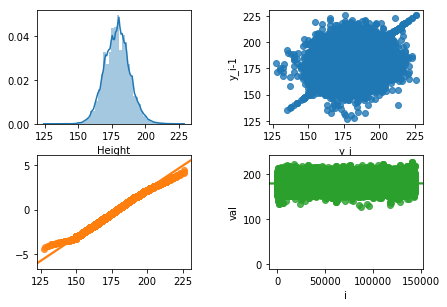

```python
multiplePlots(heights)
```

The plot of male heights follows an approximately normal distribution and is unimodal.

Male Weight Plots:

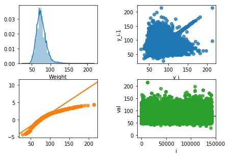

```python
multiplePlots(weights)
```

The plot of male weights is skewed to the right, meaning there are a few heavier athletes who "pull" the curve to the right. The mean is sensitive to outliers, while the median is not, which is why the mean is greater than the median in this instance. This plot of male weights is also unimodal.

Male Age Plots:

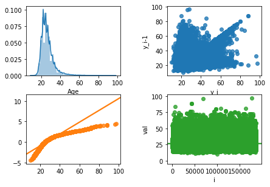

```python
multiplePlots(ages)
```

The plot of male ages is also skewed to the right meaning that the mean is greater than the median. Again, the mean is sensitive to outliers, so older athletes are "pulling" the bell curve to the right side. Finally, this plot of male ages is unimodal

### Q3 Which female athlete competed in the most number of events? (5pt)

In which events did the athelete participate, and for what range of years? Which country did the athlete represent?

Eliminate all males from the dataset:

```python
only_female_olympics = olympics[olympics['Sex'] == 'F']
```

Exploratory Analysis: Who is the female that competed in the most number of events?

```python
only_female_olympics['Name']\
    .value_counts()\
    .head(1)
```

```
Oksana Aleksandrovna Chusovitina    29
Name: Name, dtype: int64
```

Initialize a variable for "OAC" to track range of years, country and events:

```python
top_athlete = 'Oksana Aleksandrovna Chusovitina'

top_athlete_info = only_female_olympics\
                        [only_female_olympics['Name'] == top_athlete]
```

Range of years "OAC" participated in:

```python
top_athlete_info['Year'].min()
```

```
1992
```

```python
top_athlete_info['Year'].max()
```

```
2016
```

Events "OAC" participated in:

```python
top_athlete_info['Event'].unique()
```

```
array(["Gymnastics Women's Individual All-Around",
       "Gymnastics Women's Team All-Around",
       "Gymnastics Women's Floor Exercise",
       "Gymnastics Women's Horse Vault", "Gymnastics Women's Uneven Bars",
       "Gymnastics Women's Balance Beam"], dtype=object)
```

Countries "OAC" represented:

```python
top_athlete_info['NOC'].unique()
```

```
array(['EUN', 'UZB', 'GER'], dtype=object)
```

Oksana Aleksandrovna Chusovitina (OAC) is the female athlete who has competed in the most number of events throughout this Olympic history dataset. She particpated from 1992 to 2016, while taking place in 29 events. Oksana Aleksandrovna Chusovitina has particpated in: "Gymnastics Women's Individual All-Around", "Gymnastics Women's Team All-Around","Gymnastics Women's Floor Exercise","Gymnastics Women's Horse Vault", "Gymnastics Women's Uneven Bars", and "Gymnastics Women's Balance Beam". Finally, she has reprsented the EUN, UZB, and GER, which stands for the "Unified Team", Uzbekistan, and Germany, respectively.

### Q4 Which sport has the lowest median athlete age? (5pt)

To determine this, you might want to calculate and plot the median age for each sport. You may want to sort the axes appropriately for your analysis.

Groupby sport and calculate lowest median age using describe:

```python
sport_med_age = olympics.groupby('Sport')['Age']\
                        .median()\
```

```python
sport_med_age.sort_values()\
             .head()
```

```
Sport
Rhythmic Gymnastics      18.0
Swimming                 20.0
Synchronized Swimming    22.0
Figure Skating           22.0
Diving                   22.0
Name: Age, dtype: float64
```

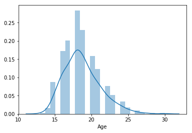

```python
lowest_med = olympics[olympics['Sport'].astype(str) == 'Rhythmic Gymnastics']\

sns.distplot(lowest_med['Age'])
```

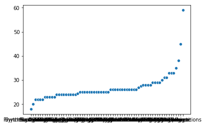

```python
sns.scatterplot(data = sport_med_age.sort_values())
```

Rhythmic Gymnastics has the lowest median athlete age of 18 years old. According to my histogram, this does make sense because the peak in the unimodal distribution of ages for "Rhythmic Gymnastics" is centered around 18 with a slightly right skew.

### Q5 Which countries have more female medalists than male medalists? (5pt)

Filter out all athletes who did not win a medal:

```python
olympics_cleaned = olympics[olympics['Medal'].notnull()]
```

(NOT DOUBLE COUNTING MEDALISTS)

Filter dataframe to only female medalists, then drop duplicates so medalists do not REPEAT, then groupby "NOC" to get the counts for each female medalist by country (and rename 'Name' to "Female_Count")

NOTE: I used "NOC" because there were examples of China, China-1, China-2, so to avoid re-organization I grouped by "NOC"

```python
olympics_cleaned_females = olympics_cleaned[olympics_cleaned['Sex'] == 'F']
olympics_cleaned_females_drop_dup = olympics_cleaned_females[['Name','NOC']]\
                                            .drop_duplicates()
female_count = olympics_cleaned_females_drop_dup.groupby(['NOC'])\
                                                .count()\
                                                .rename(columns = {'Name': 'Female_Count'})
```

(NOT DOUBLE COUNTING MEDALISTS)

Filter dataframe to only male medalists, then drop duplicates so medalists do not REPEAT, then groupby "NOC" to get the counts for each male medalist by country (and rename 'Name' to "Male_Count")

NOTE: I used "NOC" because there were examples of China, China-1, China-2, so to avoid re-organization I grouped by "NOC"

```python
olympics_cleaned_males = olympics_cleaned[olympics_cleaned['Sex'] == 'M']
olympics_cleaned_males_drop_dup = olympics_cleaned_males[['Name','NOC']]\
                                            .drop_duplicates()
male_count = olympics_cleaned_males_drop_dup.groupby(['NOC'])\
                                            .count()\
                                            .rename(columns = {'Name': 'Male_Count'})
```

(NOT DOUBLE COUNTING MEDALISTS)

Concatenate the male and female count into the dataframe 'sex_comparison', then filter to only countries where there are more female medalists than male medalists

```python
sex_comparison = pd.concat([female_count,male_count],axis = 'columns', sort = True)
females_over_males = sex_comparison[sex_comparison['Female_Count'] > sex_comparison['Male_Count']]
females_over_males
```

|  | Female_Count | Male_Count |
| --- | --- | --- |
| BLR | 58.0 | 43.0 |
| CHN | 457.0 | 199.0 |
| PER | 12.0 | 3.0 |
| SGP | 3.0 | 2.0 |
| UKR | 84.0 | 83.0 |

The countries that have more female medalists than male medalists are: BLR, CHN, PER, SGP, and UKR (Belarus, China, Peru, Singapore, and Ukraine, respectively). In this case I was able to filter by unique medalists, so medalists were not double counted for each country. Previously, I did not account for this, so there were more countries where female medalists were greater than male medalists because they were being double-counted. Oksana Aleksandrovna Chusovitina (OAC) has participated in the Olympics under multiple countries, so she may also inflate the data, but rarely enough females are double counted across different countries.

### Q6 Which country won the most medal points in the 2010 Winter Olympics? (5pt)

Rank each country by a score, where 3 points are assigned for a gold medal, 2 points for silver, and 1 point for bronze.

Filter DF to the 2010 Winter Olympics (only winter in 2010):

```python
olympics_cleaned_2010 = olympics[olympics['Year'].astype(str) == '2010']
```

Generate dummy variables for bronze, silver and gold (ignored NaN's because they will be 0,0,0):

```python
olympics_dummy_v = pd.get_dummies(olympics_cleaned_2010['Medal'])
```

Concatenated the dummy variables to the Olympics DF of 2010 athletes:

```python
olympics_agg = pd.concat(
                        [olympics_cleaned_2010 , olympics_dummy_v] \
                         ,axis = "columns"
)
```

Create a new column "Medal Count", which multiplies each dummy variable column by their respective ranking points (each column either has a 0 or a 1, so adding will not skew this new column):

```python
olympics_agg['Medal Count'] = ( olympics_agg['Bronze'].astype(float)*1 \
                               +olympics_agg['Silver'].astype(float)*2 \
                               +olympics_agg['Gold'].astype(float)*3 )
```

```python
olympics_agg
```

| ID | Name | Sex | Age | Height | Weight | Team | NOC | Games | Year | Season | City | Sport | Event | Medal | Bronze | Gold | Silver | Medal Count |
| --- | --- | --- | --- | --- | --- | --- | --- | --- | --- | --- | --- | --- | --- | --- | --- | --- | --- | --- |
| 121 | Muhammad Abbas | M | 23.0 | 168.0 | 55.0 | Pakistan | PAK | 2010 Winter | 2010 | Winter | Vancouver | Alpine Skiing | Alpine Skiing Men's Giant Slalom | NaN | 0 | 0 | 0 | 0.0 |
| 145 | Jeremy Abbott | M | 24.0 | 175.0 | 70.0 | United States | USA | 2010 Winter | 2010 | Winter | Vancouver | Figure Skating | Figure Skating Men's Singles | NaN | 0 | 0 | 0 | 0.0 |
| 452 | Enver Nazymovych Ablaiev | M | 30.0 | 169.0 | 68.0 | Ukraine | UKR | 2010 Winter | 2010 | Winter | Vancouver | Freestyle Skiing | Freestyle Skiing Men's Aerials | NaN | 0 | 0 | 0 | 0.0 |
| 532 | Iason Abramashvili | M | 21.0 | 176.0 | 82.0 | Georgia | GEO | 2010 Winter | 2010 | Winter | Vancouver | Alpine Skiing | Alpine Skiing Men's Giant Slalom | NaN | 0 | 0 | 0 | 0.0 |
| 532 | Iason Abramashvili | M | 21.0 | 176.0 | 82.0 | Georgia | GEO | 2010 Winter | 2010 | Winter | Vancouver | Alpine Skiing | Alpine Skiing Men's Slalom | NaN | 0 | 0 | 0 | 0.0 |
| 534 | Oleksandr Volodymyrovych Abramenko | M | 21.0 | 180.0 | 82.0 | Ukraine | UKR | 2010 Winter | 2010 | Winter | Vancouver | Freestyle Skiing | Freestyle Skiing Men's Aerials | NaN | 0 | 0 | 0 | 0.0 |
| 535 | Yevgeny Sergeyevich Abramenko | M | 22.0 | 181.0 | 80.0 | Belarus | BLR | 2010 Winter | 2010 | Winter | Vancouver | Biathlon | Biathlon Men's 10 kilometres Sprint | NaN | 0 | 0 | 0 | 0.0 |
| 535 | Yevgeny Sergeyevich Abramenko | M | 22.0 | 181.0 | 80.0 | Belarus | BLR | 2010 Winter | 2010 | Winter | Vancouver | Biathlon | Biathlon Men's 12.5 kilometres Pursuit | NaN | 0 | 0 | 0 | 0.0 |
| 535 | Yevgeny Sergeyevich Abramenko | M | 22.0 | 181.0 | 80.0 | Belarus | BLR | 2010 Winter | 2010 | Winter | Vancouver | Biathlon | Biathlon Men's 20 kilometres | NaN | 0 | 0 | 0 | 0.0 |
| 535 | Yevgeny Sergeyevich Abramenko | M | 22.0 | 181.0 | 80.0 | Belarus | BLR | 2010 Winter | 2010 | Winter | Vancouver | Biathlon | Biathlon Men's 4 x 7.5 kilometres Relay | NaN | 0 | 0 | 0 | 0.0 |
| 548 | Yekaterina Konstantinovna Abramova | F | 27.0 | 167.0 | 65.0 | Russia | RUS | 2010 Winter | 2010 | Winter | Vancouver | Speed Skating | Speed Skating Women's 1,500 metres | NaN | 0 | 0 | 0 | 0.0 |
| 550 | Dmitry Vladimirovich Abramovich | M | 27.0 | 182.0 | 96.0 | Russia-2 | RUS | 2010 Winter | 2010 | Winter | Vancouver | Bobsleigh | Bobsleigh Men's Two | NaN | 0 | 0 | 0 | 0.0 |
| 550 | Dmitry Vladimirovich Abramovich | M | 27.0 | 182.0 | 96.0 | Russia-1 | RUS | 2010 Winter | 2010 | Winter | Vancouver | Bobsleigh | Bobsleigh Men's Four | NaN | 0 | 0 | 0 | 0.0 |
| 671 | Ghassan Achi | M | 16.0 | 168.0 | 60.0 | Lebanon | LIB | 2010 Winter | 2010 | Winter | Vancouver | Alpine Skiing | Alpine Skiing Men's Giant Slalom | NaN | 0 | 0 | 0 | 0.0 |
| 671 | Ghassan Achi | M | 16.0 | 168.0 | 60.0 | Lebanon | LIB | 2010 Winter | 2010 | Winter | Vancouver | Alpine Skiing | Alpine Skiing Men's Slalom | NaN | 0 | 0 | 0 | 0.0 |
| 736 | Brigitte Acton (-Smith) | F | 24.0 | 168.0 | 63.0 | Canada | CAN | 2010 Winter | 2010 | Winter | Vancouver | Alpine Skiing | Alpine Skiing Women's Slalom | NaN | 0 | 0 | 0 | 0.0 |
| 956 | Richard "Richy" Adjei | M | 27.0 | 190.0 | 110.0 | Germany-2 | GER | 2010 Winter | 2010 | Winter | Vancouver | Bobsleigh | Bobsleigh Men's Two | Silver | 0 | 0 | 1 | 2.0 |
| 956 | Richard "Richy" Adjei | M | 27.0 | 190.0 | 110.0 | Germany-2 | GER | 2010 Winter | 2010 | Winter | Vancouver | Bobsleigh | Bobsleigh Men's Four | NaN | 0 | 0 | 0 | 0.0 |
| 1085 | Maksim Sergeyevich Afinogenov | M | 30.0 | 183.0 | 88.0 | Russia | RUS | 2010 Winter | 2010 | Winter | Vancouver | Ice Hockey | Ice Hockey Men's Ice Hockey | NaN | 0 | 0 | 0 | 0.0 |
| 1181 | Meghan Christina Agosta (-Marciano) | F | 23.0 | 168.0 | 67.0 | Canada | CAN | 2010 Winter | 2010 | Winter | Vancouver | Ice Hockey | Ice Hockey Women's Ice Hockey | Gold | 0 | 1 | 0 | 3.0 |
| 1188 | Benjamin Alexandro "Ben" Agosto | M | 28.0 | 178.0 | 75.0 | United States-2 | USA | 2010 Winter | 2010 | Winter | Vancouver | Figure Skating | Figure Skating Mixed Ice Dancing | NaN | 0 | 0 | 0 | 0.0 |
| 1435 | Janne Petteri Ahonen | M | 32.0 | 184.0 | 66.0 | Finland | FIN | 2010 Winter | 2010 | Winter | Vancouver | Ski Jumping | Ski Jumping Men's Normal Hill, Individual | NaN | 0 | 0 | 0 | 0.0 |
| 1435 | Janne Petteri Ahonen | M | 32.0 | 184.0 | 66.0 | Finland | FIN | 2010 Winter | 2010 | Winter | Vancouver | Ski Jumping | Ski Jumping Men's Large Hill, Individual | NaN | 0 | 0 | 0 | 0.0 |
| 1501 | Sarah Catherine Ainsworth | F | 24.0 | 170.0 | 61.0 | Great Britain | GBR | 2010 Winter | 2010 | Winter | Vancouver | Freestyle Skiing | Freestyle Skiing Women's Aerials | NaN | 0 | 0 | 0 | 0.0 |
| 2348 | Johnny Albertsen | M | 32.0 | 170.0 | 75.0 | Denmark | DEN | 2010 Winter | 2010 | Winter | Vancouver | Alpine Skiing | Alpine Skiing Men's Downhill | NaN | 0 | 0 | 0 | 0.0 |
| 2348 | Johnny Albertsen | M | 32.0 | 170.0 | 75.0 | Denmark | DEN | 2010 Winter | 2010 | Winter | Vancouver | Alpine Skiing | Alpine Skiing Men's Super G | NaN | 0 | 0 | 0 | 0.0 |
| 2373 | Kilian Albrecht | M | 36.0 | 181.0 | 72.0 | Bulgaria | BUL | 2010 Winter | 2010 | Winter | Vancouver | Alpine Skiing | Alpine Skiing Men's Slalom | NaN | 0 | 0 | 0 | 0.0 |
| 2414 | Chimene Mary "Chemmy" Alcott (-Crawford) | F | 27.0 | 169.0 | 69.0 | Great Britain | GBR | 2010 Winter | 2010 | Winter | Vancouver | Alpine Skiing | Alpine Skiing Women's Downhill | NaN | 0 | 0 | 0 | 0.0 |
| 2414 | Chimene Mary "Chemmy" Alcott (-Crawford) | F | 27.0 | 169.0 | 69.0 | Great Britain | GBR | 2010 Winter | 2010 | Winter | Vancouver | Alpine Skiing | Alpine Skiing Women's Super G | NaN | 0 | 0 | 0 | 0.0 |
| 2414 | Chimene Mary "Chemmy" Alcott (-Crawford) | F | 27.0 | 169.0 | 69.0 | Great Britain | GBR | 2010 Winter | 2010 | Winter | Vancouver | Alpine Skiing | Alpine Skiing Women's Giant Slalom | NaN | 0 | 0 | 0 | 0.0 |
| ... | ... | ... | ... | ... | ... | ... | ... | ... | ... | ... | ... | ... | ... | ... | ... | ... | ... | ... |
| 135083 | Sergey Olegovich Zinovyev | M | 29.0 | 178.0 | 81.0 | Russia | RUS | 2010 Winter | 2010 | Winter | Vancouver | Ice Hockey | Ice Hockey Men's Ice Hockey | NaN | 0 | 0 | 0 | 0.0 |
| 135163 | Luiza Zotkowska | F | 23.0 | 160.0 | 52.0 | Poland | POL | 2010 Winter | 2010 | Winter | Vancouver | Speed Skating | Speed Skating Women's 1,500 metres | NaN | 0 | 0 | 0 | 0.0 |
| 135163 | Luiza Zotkowska | F | 23.0 | 160.0 | 52.0 | Poland | POL | 2010 Winter | 2010 | Winter | Vancouver | Speed Skating | Speed Skating Women's 3,000 metres | NaN | 0 | 0 | 0 | 0.0 |
| 135163 | Luiza Zotkowska | F | 23.0 | 160.0 | 52.0 | Poland | POL | 2010 Winter | 2010 | Winter | Vancouver | Speed Skating | Speed Skating Women's Team Pursuit (6 laps) | Bronze | 1 | 0 | 0 | 1.0 |
| 135166 | Tom Zmoray | M | 20.0 | 187.0 | 68.0 | Slovakia | SVK | 2010 Winter | 2010 | Winter | Vancouver | Ski Jumping | Ski Jumping Men's Normal Hill, Individual | NaN | 0 | 0 | 0 | 0.0 |
| 135166 | Tom Zmoray | M | 20.0 | 187.0 | 68.0 | Slovakia | SVK | 2010 Winter | 2010 | Winter | Vancouver | Ski Jumping | Ski Jumping Men's Large Hill, Individual | NaN | 0 | 0 | 0 | 0.0 |
| 135196 | Armin Zggeler | M | 36.0 | 181.0 | 88.0 | Italy | ITA | 2010 Winter | 2010 | Winter | Vancouver | Luge | Luge Men's Singles | Bronze | 1 | 0 | 0 | 1.0 |
| 135216 | Sabrina Zollinger | F | 16.0 | 162.0 | 65.0 | Switzerland | SUI | 2010 Winter | 2010 | Winter | Vancouver | Ice Hockey | Ice Hockey Women's Ice Hockey | NaN | 0 | 0 | 0 | 0.0 |
| 135263 | Cristian Zorzi | M | 37.0 | 184.0 | 75.0 | Italy | ITA | 2010 Winter | 2010 | Winter | Vancouver | Cross Country Skiing | Cross Country Skiing Men's 4 x 10 kilometres R... | NaN | 0 | 0 | 0 | 0.0 |
| 135263 | Cristian Zorzi | M | 37.0 | 184.0 | 75.0 | Italy | ITA | 2010 Winter | 2010 | Winter | Vancouver | Cross Country Skiing | Cross Country Skiing Men's Team Sprint | NaN | 0 | 0 | 0 | 0.0 |
| 135293 | Natko Zrni-Dim | M | 23.0 | 175.0 | 80.0 | Croatia | CRO | 2010 Winter | 2010 | Winter | Vancouver | Alpine Skiing | Alpine Skiing Men's Downhill | NaN | 0 | 0 | 0 | 0.0 |
| 135293 | Natko Zrni-Dim | M | 23.0 | 175.0 | 80.0 | Croatia | CRO | 2010 Winter | 2010 | Winter | Vancouver | Alpine Skiing | Alpine Skiing Men's Super G | NaN | 0 | 0 | 0 | 0.0 |
| 135293 | Natko Zrni-Dim | M | 23.0 | 175.0 | 80.0 | Croatia | CRO | 2010 Winter | 2010 | Winter | Vancouver | Alpine Skiing | Alpine Skiing Men's Giant Slalom | NaN | 0 | 0 | 0 | 0.0 |
| 135293 | Natko Zrni-Dim | M | 23.0 | 175.0 | 80.0 | Croatia | CRO | 2010 Winter | 2010 | Winter | Vancouver | Alpine Skiing | Alpine Skiing Men's Slalom | NaN | 0 | 0 | 0 | 0.0 |
| 135293 | Natko Zrni-Dim | M | 23.0 | 175.0 | 80.0 | Croatia | CRO | 2010 Winter | 2010 | Winter | Vancouver | Alpine Skiing | Alpine Skiing Men's Combined | NaN | 0 | 0 | 0 | 0.0 |
| 135343 | Aleksandr Yuryevich Zubkov | M | 35.0 | 189.0 | 102.0 | Russia-1 | RUS | 2010 Winter | 2010 | Winter | Vancouver | Bobsleigh | Bobsleigh Men's Two | Bronze | 1 | 0 | 0 | 1.0 |
| 135343 | Aleksandr Yuryevich Zubkov | M | 35.0 | 189.0 | 102.0 | Russia-2 | RUS | 2010 Winter | 2010 | Winter | Vancouver | Bobsleigh | Bobsleigh Men's Four | NaN | 0 | 0 | 0 | 0.0 |
| 135365 | Mats Andr Zuccarello-Aasen | M | 22.0 | 171.0 | 74.0 | Norway | NOR | 2010 Winter | 2010 | Winter | Vancouver | Ice Hockey | Ice Hockey Men's Ice Hockey | NaN | 0 | 0 | 0 | 0.0 |
| 135467 | Silvan Zurbriggen | M | 28.0 | 185.0 | 94.0 | Switzerland | SUI | 2010 Winter | 2010 | Winter | Vancouver | Alpine Skiing | Alpine Skiing Men's Slalom | NaN | 0 | 0 | 0 | 0.0 |
| 135467 | Silvan Zurbriggen | M | 28.0 | 185.0 | 94.0 | Switzerland | SUI | 2010 Winter | 2010 | Winter | Vancouver | Alpine Skiing | Alpine Skiing Men's Combined | Bronze | 1 | 0 | 0 | 1.0 |
| 135485 | Stepan Olegovich Zuyev | M | 21.0 | 189.0 | 90.0 | Russia | RUS | 2010 Winter | 2010 | Winter | Vancouver | Alpine Skiing | Alpine Skiing Men's Downhill | NaN | 0 | 0 | 0 | 0.0 |
| 135485 | Stepan Olegovich Zuyev | M | 21.0 | 189.0 | 90.0 | Russia | RUS | 2010 Winter | 2010 | Winter | Vancouver | Alpine Skiing | Alpine Skiing Men's Super G | NaN | 0 | 0 | 0 | 0.0 |
| 135485 | Stepan Olegovich Zuyev | M | 21.0 | 189.0 | 90.0 | Russia | RUS | 2010 Winter | 2010 | Winter | Vancouver | Alpine Skiing | Alpine Skiing Men's Giant Slalom | NaN | 0 | 0 | 0 | 0.0 |
| 135485 | Stepan Olegovich Zuyev | M | 21.0 | 189.0 | 90.0 | Russia | RUS | 2010 Winter | 2010 | Winter | Vancouver | Alpine Skiing | Alpine Skiing Men's Slalom | NaN | 0 | 0 | 0 | 0.0 |
| 135485 | Stepan Olegovich Zuyev | M | 21.0 | 189.0 | 90.0 | Russia | RUS | 2010 Winter | 2010 | Winter | Vancouver | Alpine Skiing | Alpine Skiing Men's Combined | NaN | 0 | 0 | 0 | 0.0 |
| 135492 | Veronika Zuzulov (-Velez) | F | 25.0 | 172.0 | 72.0 | Slovakia | SVK | 2010 Winter | 2010 | Winter | Vancouver | Alpine Skiing | Alpine Skiing Women's Giant Slalom | NaN | 0 | 0 | 0 | 0.0 |
| 135492 | Veronika Zuzulov (-Velez) | F | 25.0 | 172.0 | 72.0 | Slovakia | SVK | 2010 Winter | 2010 | Winter | Vancouver | Alpine Skiing | Alpine Skiing Women's Slalom | NaN | 0 | 0 | 0 | 0.0 |
| 135496 | Veronika Zvaiov | F | 21.0 | 176.0 | 62.0 | Czech Republic | CZE | 2010 Winter | 2010 | Winter | Vancouver | Biathlon | Biathlon Women's 7.5 kilometres Sprint | NaN | 0 | 0 | 0 | 0.0 |
| 135500 | Kristaps Zvejnieks | M | 17.0 | 185.0 | 87.0 | Latvia | LAT | 2010 Winter | 2010 | Winter | Vancouver | Alpine Skiing | Alpine Skiing Men's Giant Slalom | NaN | 0 | 0 | 0 | 0.0 |
| 135500 | Kristaps Zvejnieks | M | 17.0 | 185.0 | 87.0 | Latvia | LAT | 2010 Winter | 2010 | Winter | Vancouver | Alpine Skiing | Alpine Skiing Men's Slalom | NaN | 0 | 0 | 0 | 0.0 |

4402 rows × 18 columns

Groupby "NOC", filter to only medal count, sum the total for each countries rank, and then finally sort in descending order:

NOTE: I used "NOC" because there were examples of China, China-1, China-2, so to avoid re-organization I grouped by "NOC"

```python
olympics_agg.groupby('NOC')['Medal Count']\
            .sum()\
            .sort_values(ascending = False)\
            .head(1)
```

```
NOC
CAN    239.0
Name: Medal Count, dtype: float64
```

The country that won the most "medal points" during the 2010 Winter Olympics was Canada with 239 points.

### BONUS 5 pt: For each year in which games were held, what proportion of gold medals did the host country win?

You will need to combine multiple datasets to complete the analysis. We suggest using the following resource:

- https://en.wikipedia.org/wiki/List_of_Olympic_Games_host_cities (note: you can use the [read_html](https://pandas.pydata.org/pandas-docs/stable/generated/pandas.read_html.html) function to load the data into a DataFrame.

```python
url_1 = 'https://www.iban.com/country-codes'
codes = pd.read_html(url_1, header = 0)
country_codes =  codes[0][['Country','Alpha-3 code']]
```

```python
url = 'https://en.wikipedia.org/wiki/List_of_Olympic_Games_host_cities'
addit_df = pd.read_html(url, header = 0)
olympics_loc = addit_df[1][['Year','City','Country']]
olympics_loc_up_to_date = olympics_loc[olympics_loc['Year'].astype(int) <= 2016]
```

```python
olympics_agg_ = olympics.merge(olympics_loc_up_to_date)
```

```python
combined_abbrev = olympics_agg_.merge(country_codes)
combined_abbrev[(combined_abbrev['Year'].astype(int)>1952) &(combined_abbrev['Medal'] == 'Gold') & (combined_abbrev[combined_abbrev['NOC'] == combined_abbrev['Alpha-3 code']]) ]
# gold_count = olympics[olympics['Medal'] == 'Gold'].groupby(['Year','Medal']).count()['Event']
# medal_count_by_noc_year = combined_abbrev[combined_abbrev['NOC'] == combined_abbrev['Alpha-3 code']]
# all_medals = medal_count_by_noc_year.groupby(['NOC','Medal']).count()
# only_gold_and_home_country = all_medals.unstack()['Name']['Gold'].reset_index()


#.groupby(['NOC', 'Year'])['Medal'].count()
```

```python
total_medals_vs_home_medals = pd.concat([only_gold_and_home_country,gold_count.reset_index()],axis = 'columns')
total_medals_vs_home_medals
```

[output not shown]

```python
total_medals_vs_home_medals['Proportion_Of_Gold'] = total_medals_vs_home_medals['Gold']/total_medals_vs_home_medals['Event']
total_medals_vs_home_medals.dropna()
```

[output not shown]

## Please submit your completed notebook in HTML format via Canvas.